# MR-PheWAS Analysis: MR Results Visualisation

Dexamethasone-Stimulated Human Array Project

Anastasiia Hryhorzhevska

Max Planck Institute of Psychiatry  
anastasiia_hry@psych.mpg.de

Last compiled on 21 August, 2022

# 1: Load and prepare data

The selected exposure list is loaded for later visualisation:

MR result data is loaded:

```r
mr.res <- fread("~/bio/code/mpip/dex-stim-human-array/output/data/integrative/phewas/10_cell_type_groups/mr_results_clumped.rds")
```

# 2 Processing

## 2.1 Annotation

Results are annotated in multiple steps.

First, information on traits and batches are merged back from the selected exposures file:

| exposure | outcome | id.exposure | id.outcome | samplesize | SNP | b | se | p | fdr | exposure.group | trait | batch |
| --- | --- | --- | --- | --- | --- | --- | --- | --- | --- | --- | --- | --- |
| no_base_Neu_cg27050153 | Vertical cup-disc ratio \|\| id:ebi-a-GCST004075 | 1rlJEA | ebi-a-GCST004075 | 23899 | rs12588072 | -0.10484884 | 0.1397984 | 0.4532547 | 0.9483568 | no_base_Neu | Vertical cup-disc ratio | ebi-a |
| no_base_Neu_cg27050153 | Tumor necrosis factor beta levels \|\| id:ebi-a-GCST004425 | 1rlJEA | ebi-a-GCST004425 | 1559 | rs12588072 | 0.03494961 | 4.0716298 | 0.9931513 | 0.9994437 | no_base_Neu | Tumor necrosis factor beta levels | ebi-a |
| no_base_Neu_cg27050153 | Stromal-cell-derived factor 1 alpha levels \|\| id:ebi-a-GCST004427 | 1rlJEA | ebi-a-GCST004427 | 5998 | rs12588072 | -0.22717248 | 1.8348546 | 0.9014661 | 0.9938165 | no_base_Neu | Stromal-cell-derived factor 1 alpha levels | ebi-a |
| no_base_Neu_cg27050153 | Stem cell growth factor beta levels \|\| id:ebi-a-GCST004428 | 1rlJEA | ebi-a-GCST004428 | 3682 | rs12588072 | 0.03494961 | 2.6823827 | 0.9896044 | 0.9988061 | no_base_Neu | Stem cell growth factor beta levels | ebi-a |
| no_base_Neu_cg27050153 | Platelet-derived growth factor BB levels \|\| id:ebi-a-GCST004432 | 1rlJEA | ebi-a-GCST004432 | 8293 | rs12588072 | 0.55045639 | 1.7824302 | 0.7574558 | 0.9872725 | no_base_Neu | Platelet-derived growth factor BB levels | ebi-a |
| no_base_Neu_cg27050153 | Macrophage inflammatory protein 1b levels \|\| id:ebi-a-GCST004433 | 1rlJEA | ebi-a-GCST004433 | 8243 | rs12588072 | -0.53298158 | 1.7824302 | 0.7649251 | 0.9877993 | no_base_Neu | Macrophage inflammatory protein 1b levels | ebi-a |

Clean extra hyphen from batch data:

| exposure | outcome | id.exposure | id.outcome | samplesize | SNP | b | se | p | fdr | exposure.group | trait | batch |
| --- | --- | --- | --- | --- | --- | --- | --- | --- | --- | --- | --- | --- |
| no_base_Neu_cg27050153 | Vertical cup-disc ratio \|\| id:ebi-a-GCST004075 | 1rlJEA | ebi-a-GCST004075 | 23899 | rs12588072 | -0.10484884 | 0.1397984 | 0.4532547 | 0.9483568 | no_base_Neu | Vertical cup-disc ratio | ebi-a |
| no_base_Neu_cg27050153 | Tumor necrosis factor beta levels \|\| id:ebi-a-GCST004425 | 1rlJEA | ebi-a-GCST004425 | 1559 | rs12588072 | 0.03494961 | 4.0716298 | 0.9931513 | 0.9994437 | no_base_Neu | Tumor necrosis factor beta levels | ebi-a |
| no_base_Neu_cg27050153 | Stromal-cell-derived factor 1 alpha levels \|\| id:ebi-a-GCST004427 | 1rlJEA | ebi-a-GCST004427 | 5998 | rs12588072 | -0.22717248 | 1.8348546 | 0.9014661 | 0.9938165 | no_base_Neu | Stromal-cell-derived factor 1 alpha levels | ebi-a |
| no_base_Neu_cg27050153 | Stem cell growth factor beta levels \|\| id:ebi-a-GCST004428 | 1rlJEA | ebi-a-GCST004428 | 3682 | rs12588072 | 0.03494961 | 2.6823827 | 0.9896044 | 0.9988061 | no_base_Neu | Stem cell growth factor beta levels | ebi-a |
| no_base_Neu_cg27050153 | Platelet-derived growth factor BB levels \|\| id:ebi-a-GCST004432 | 1rlJEA | ebi-a-GCST004432 | 8293 | rs12588072 | 0.55045639 | 1.7824302 | 0.7574558 | 0.9872725 | no_base_Neu | Platelet-derived growth factor BB levels | ebi-a |
| no_base_Neu_cg27050153 | Macrophage inflammatory protein 1b levels \|\| id:ebi-a-GCST004433 | 1rlJEA | ebi-a-GCST004433 | 8243 | rs12588072 | -0.53298158 | 1.7824302 | 0.7649251 | 0.9877993 | no_base_Neu | Macrophage inflammatory protein 1b levels | ebi-a |

The exposure.group variable is recoded with proper names:

The CpG column is created based on the exposure label:

```r
mr.res.ao$cpg <- unlist(strsplit(mr.res.ao$exposure, "_"))[seq(from = 4, to = 2*nrow(mr.res.ao), by = 4)]
```

```
Error in set(x, j = name, value = value) :
  Supplied 27842 items to be assigned to 55684 items of column 'cpg'. If you wish to 'recycle' the RHS please use rep() to make this intent clear to readers of your code.
```

The number of phenotypes analysed per batch is as follows:

| batch | n_outcomes |
| --- | --- |
| ebi-a | 1054 |
| ieu-a | 115 |
| ieu-b | 38 |
| ukb-a | 221 |
| ukb-b | 2146 |
| ukb-d | 783 |

Overall, there is no indication that there are more PheWAS hits in any of the exposure groups:

```r
chisq.test(sig.table)
```

```
    Pearson's Chi-squared test

data:  sig.table
X-squared = 1.6203, df = 4, p-value = 0.8051
```

Second, FDR-corrected significant results are exported and saved:

```r
nrow(mr.res.ao.fdr.sig)
```

```
[1] 246
```

These results are annotated manually to group outcome traits. Annotated data are read back in and categories shown in a frequency table:

```r
table(mr.res.ao.fdr.sig$trait_category)
```

```
       Biomarker  Body morphology          Disease    Immune system Neuro-behavioral        Nutrition
              70               37               69               50                5                1
           Other
              14
```

Results are now checked to see if there are differences in distribution of exposure SNP groups per category:

```r
cross_table %>% print()
```

```
                  trait_category
exposure.group     Biomarker Body morphology Disease Immune system Neuro-behavioral Nutrition Other
  no_base_Bmem+Bnv        18               5      32            15                1         0     4
  no_base_CD4mem           1               3      10             2                1         0     1
  no_base_CD4nv           15              10       7            14                0         0     2
  no_base_CD8mem           3               4       1             0                0         0     0
  no_base_Neu             33              15      19            19                3         1     7
```

The respective distributions are visualised in a bar chart:

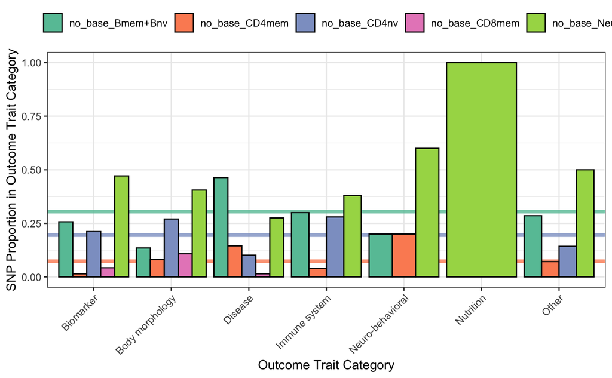

# 2.2: Most frequent traits

The most frequently observed outcome traits across the individual functional groups are as follows:

[figure not shown]

```r
mr.res.ao.fdr.sig %>%
   group_by(exposure.group, trait) %>%
   summarize(n_trait = n()) %>%
   arrange(desc(n_trait)) %>%
   filter(trait %in% head(trait, 5)) %>%
   ungroup() %>%
   mutate(trait = factor(trait, levels = rev(unique(trait)))) %>%
   ggplot(aes(x = trait, y = n_trait)) +
   geom_bar(aes(fill = exposure.group), stat = "identity", col = "black",
            position = position_dodge()) +
   facet_wrap(.~exposure.group) +
   labs(x = "", y = "No. of FDR-corrected associations") +
   scale_fill_brewer(palette = "Set2") +
   coord_flip() +
   theme_bw() +
   theme(legend.position = "none",
         legend.title = element_blank(),
         legend.background = element_blank(),
         plot.background = element_blank())
```

# 2.2 SNP/Gene Identification

SNPs that show particularly frequent associations with phenotypes (generally and specifically in trait categories) are extracted:

| trait_category | SNP | cpg | exposure.group | n_phenotypes | prop | n_crosscategory | phenotype_hits |
| --- | --- | --- | --- | --- | --- | --- | --- |
| Biomarker | rs3820484 | cg17227839 | no_base_Neu | 14 | 0.20000000 | 6 | Reticulocyte percentage; Mean sphered cell volume; High light scatter reticulocyte percentage; triglycerides; Mean corpuscular hemoglobin concentration; Low density lipoprotein cholesterol levels; LDL… |
| Biomarker | rs3820484 | cg17227839 | no_base_CD4nv | 14 | 0.20000000 | 6 | Reticulocyte percentage; Mean sphered cell volume; High light scatter reticulocyte percentage; triglycerides; Mean corpuscular hemoglobin concentration; Low density lipoprotein cholesterol levels; LDL… |
| Biomarker | rs1074663 | cg21771250 | no_base_Neu | 12 | 0.17142857 | 5 | Ankle spacing width; Reticulocyte count; Mean corpuscular haemoglobin; Mean corpuscular volume; High light scatter reticulocyte percentage; Red blood cell (erythrocyte) count; 3mm weak meridian (left)… |
| Biomarker | rs632576 | cg02571055 | no_base_Bmem+Bnv | 9 | 0.12857143 | 4 | FVC; Forced vital capacity (FVC) Best measure; Hand grip strength (left); Heel bone mineral density (BMD) T-score automated; 3mm strong meridian (right); 6mm weak meridian (right); Forced expiratory v… |
| Biomarker | rs9415931 | cg04743897 | no_base_CD8mem | 6 | 0.08571429 | 6 | Peak expiratory flow (PEF); FVC; Glycated haemoglobin |
| Body morphology | rs1074663 | cg21771250 | no_base_Neu | 10 | 0.27027027 | 5 | body mass index; Arm fat mass (left); Leg fat mass (left); Waist circumference; Weight; Leg fat percentage (left); Trunk fat-free mass; Leg fat-free mass (right); Leg fat percentage (right); Leg predi… |
| Body morphology | rs9415931 | cg04743897 | no_base_CD8mem | 8 | 0.21621622 | 6 | Arm fat-free mass (right); Leg predicted mass (right); Leg fat-free mass (right); Leg predicted mass (left) |
| Body morphology | rs9415931 | cg04743897 | no_base_CD4nv | 8 | 0.21621622 | 6 | Arm fat-free mass (right); Leg predicted mass (right); Leg fat-free mass (right); Leg predicted mass (left) |
| Body morphology | rs11227153 | cg07822010 | no_base_Neu | 3 | 0.08108108 | 1 | Height; Whole body fat-free mass; Appendicular lean mass |
| Body morphology | rs9381017 | cg23594693 | no_base_CD4nv | 3 | 0.08108108 | 3 | Leg fat-free mass (left); body mass index; Arm predicted mass (right) |

[output cut: 21 more lines]

Overall SNP hits disregarding category are also extracted:

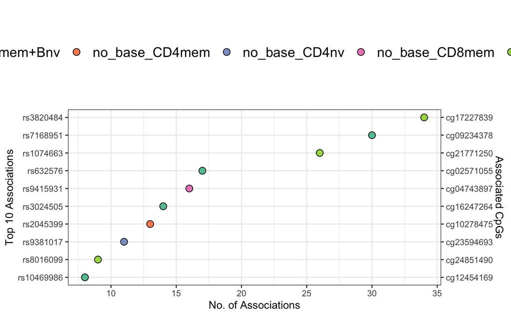

The same is conducted next per trait category:

[figure not shown]

# 2.3 Visualisation data

Visualisation data for the Shiny app is created using a subset of relevant columns from *mr_res*:

```r
vis_dat = mr.res.ao.fdr.sig %>%
   select(exposure.group, exposure, SNP, trait, batch, outcome, samplesize, b, se, p, fdr)
```

[output not shown]

The exposure variable is shortened by removing the exposure.group id:

The trait category is merged from the FDR hits:

```r
vis_dat = left_join(vis_dat, mr_res_fdrsig[, c("exposure.group", "SNP", "outcome", "trait_category")],
                    by = c("exposure.group" = "exposure.group", "SNP" = "SNP", "outcome" = "outcome"))
```

```
Error in is.data.frame(y) : object 'mr_res_fdrsig' not found
```

The p-value column is corrected to exchange all exact 0’s with *R*’s lowest number to avoid computational errors:

A new *P*-value column is created for -log10(P) values as well as the same variable with valence information from betas added:

```r
vis_dat$pval_log10 = -log10(vis_dat$p)
vis_dat$pval_log10_val = ifelse(vis_dat$b > 0, vis_dat$pval_log10, -vis_dat$pval_log10)
```

Traits are recoded to obtain proper names and data arranged by batch.label:

```r
vis_dat = arrange(vis_dat, desc(outcome), batch, trait)
vis_dat$trait = factor(vis_dat$trait, levels = unique(vis_dat$trait))
```

Data is saved again for creation of the Shiny app:

[output not shown]

[output cut: 990 more lines]

# 3: QQ-plot

```r
sort(ps)
```